# BTS 510 Lab 3

```r
library(tidyverse)
theme_set(theme_classic(base_size = 16))
```

## 1 Learning objectives

- Understand **probability** as a measure of **uncertainty**
- **Summarize** probabilities with *probability distributions*
- Think about **uncertainty** in sampling
- **Summarize** uncertainty in sampling: **Sampling distribution**

## 2 Mathematically-derived sampling distribution

- Many combinations of **population distribution** and **test statistic** have *mathematically-derived* sampling distributions
  - For example, with a **normally distributed** population ($\mathcal{N}(\mu, \sigma^2)$), the sampling distribution of the **mean** is $\bar{X} \sim \mathcal{N}(\mu, \frac{\sigma^2}{n})$
    - In this case, the *population* distribution and *sampling* distribution are the **same distribution**: Normal
    - The variance (or standard deviation) of the sampling distribution **decreases** as $n$ increases: A *larger sample* leads to a smaller, *more precise standard error*

**Note**

- There is not a mathematically-derived sampling distribution for every population distribution and test statistic
  - If you’re dealing with *unknown or unusual distributions or test statistics*, your only option may be *computational methods*

## 3 Computationally-derived sampling distribution

### 3.1 Getting started

- Set a **random number seed**
  - If you don’t do this, every time you run the code, you’ll get different numbers
  - Setting a random seed makes your simulation *replicable*
  - (I normally set a seed at the start of each document, but I moved it down here because it’s very important in this lab.)
- Load (and install, if needed) the [**infer** package](https://infer.tidymodels.org/)
  - **infer** has a function that we’ll use to *repeatedly sample*
  - There are other ways to do this, but this is very simple and works well
- Only have to do this once per document

```r
set.seed(12345)
library(infer)
```

### 3.2 Standard Normal population: $population \sim \mathcal{N}(0, 1)$

#### 3.2.1 Create a population

- `rnorm()` creates a random variable that follows a **normal** distribution
  - First argument = Number of observations (population size)
  - Second argument = $\mu$
  - Third argument = $\sigma$ (not $\sigma^2$)

```r
norm_pop <- rnorm(1000000, 0, 1)
mean(norm_pop)
```

```
[1] 0.0002941277
```

```r
sd(norm_pop)
```

```
[1] 1.001315
```

```r
var(norm_pop)
```

```
[1] 1.002632
```

#### 3.2.2 Sample from the population

- Small sample: $n$ = 10
  - `rep_sample_n()` repeatedly samples from the dataset
    - Piped (`%>%`) from the `norm_pop` dataset, so it resamples from that
    - `size = 10`: Sample size for each sample
    - `reps = 10000`: Number of repeated samples (could be larger but this is good enough to show how things work and doesn’t take too long to run)
    - `replace = TRUE`: Sample with replacement
  - `summarise(x_bar = mean(norm_pop))`: Create a data frame with each of the means from each sample
  - The `ggplot()` code creates a histogram from the data
    - Modification: `bins = 50` increases the bins to make it a little smoother
    - Modification: `xlim(-1.5, 1.5)` sets limits on the x-axis to make the plots more comparable
    - Make similar modifications in your own plots later in this document
    - We’ll spend the next 2 weeks on `ggplot()` so you’ll learn all of this (and more!)

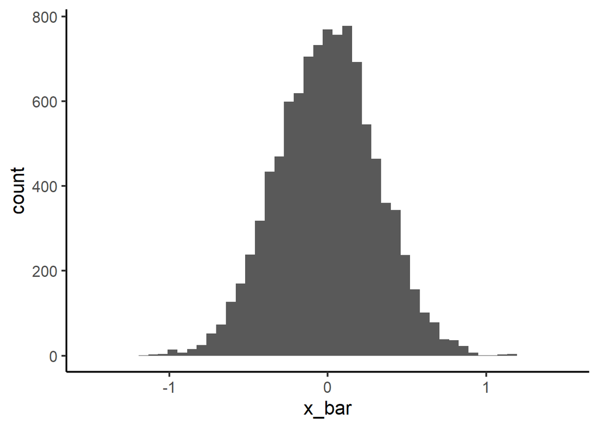

```r
norm_means10 <- data.frame(norm_pop) %>%
  rep_sample_n(size = 10, reps = 10000, replace = TRUE) %>%
  summarise(x_bar = mean(norm_pop))

ggplot(data = norm_means10, aes(x = x_bar)) +
  geom_histogram(bins = 50) +
  xlim(-1.5, 1.5)
```

- Moderate sample: $n$ = 50

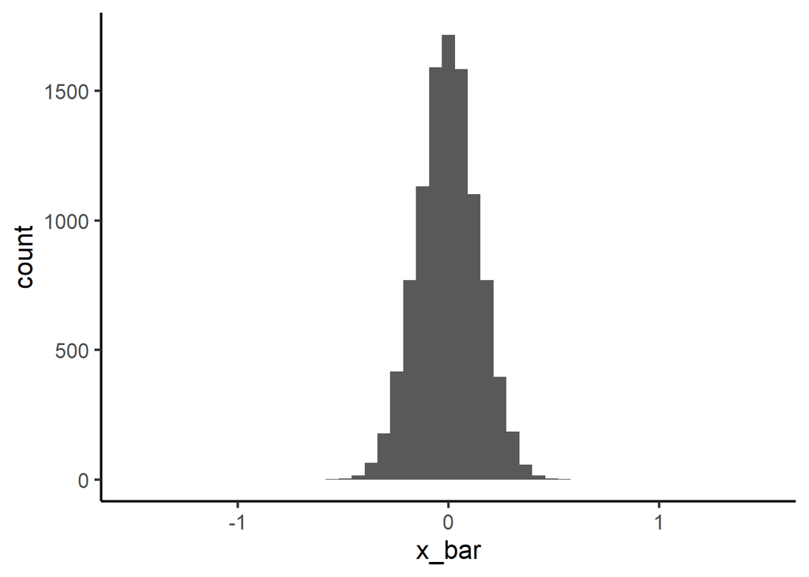

```r
norm_means50 <- data.frame(norm_pop) %>%
  rep_sample_n(size = 50, reps = 10000, replace = TRUE) %>%
  summarise(x_bar = mean(norm_pop))

ggplot(data = norm_means50, aes(x = x_bar)) +
  geom_histogram(bins = 50) +
  xlim(-1.5, 1.5)
```

- Large sample: $n$ = 100

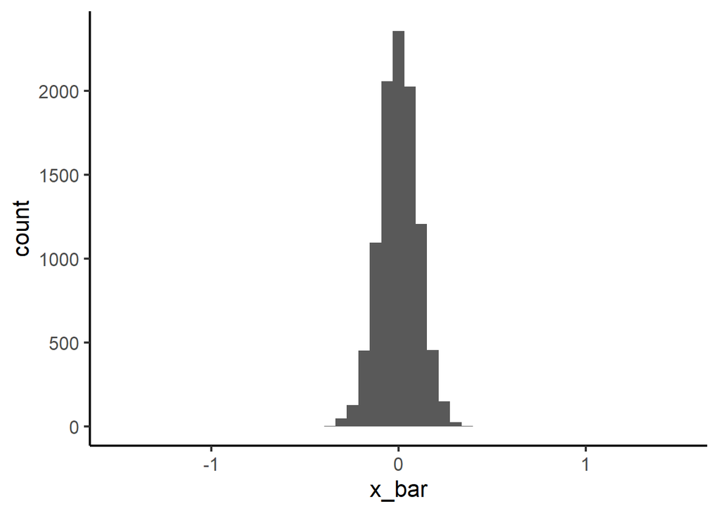

```r
norm_means100 <- data.frame(norm_pop) %>%
  rep_sample_n(size = 100, reps = 10000, replace = TRUE) %>%
  summarise(x_bar = mean(norm_pop))

ggplot(data = norm_means100, aes(x = x_bar)) +
  geom_histogram(bins = 50) +
  xlim(-1.5, 1.5)
```

#### 3.2.3 Compare estimates

- Compare means, standard deviations, and variances for each sample size

```r
mean(norm_means10$x_bar)
```

```
[1] -0.003408017
```

```r
mean(norm_means50$x_bar)
```

```
[1] -0.0009473133
```

```r
mean(norm_means100$x_bar)
```

```
[1] 0.001145927
```

```r
sd(norm_means10$x_bar)
```

```
[1] 0.3131297
```

```r
sd(norm_means50$x_bar)
```

```
[1] 0.1416664
```

```r
sd(norm_means100$x_bar)
```

```
[1] 0.100464
```

```r
var(norm_means10$x_bar)
```

```
[1] 0.09805018
```

```r
var(norm_means50$x_bar)
```

```
[1] 0.02006937
```

```r
var(norm_means100$x_bar)
```

```
[1] 0.01009301
```

- How does each value correspond to what you’d expect based on the mathematically-derived sampling distribution?
  - $\bar{X} \sim \mathcal{N}(\mu, \frac{\sigma^2}{n})$

### 3.3 Bernoulli population: $population \sim B(0.3)$

#### 3.3.1 Create a population

- `rbinom()` creates a random variable that follows a **binomial** distribution
  - First argument = Number of observations (population size)
  - Second argument = number of trials (here, just 1 for a **Bernoulli** trial)
  - Third argument = $p$ (probability of success)

```r
bernoulli_pop <- rbinom(1000000, 1, 0.3)
mean(bernoulli_pop)
```

```
[1] 0.300871
```

```r
sd(bernoulli_pop)
```

```
[1] 0.4586369
```

```r
var(bernoulli_pop)
```

```
[1] 0.2103479
```

- Copy and modify the code above to resample from this new Bernoulli population

#### 3.3.2 Sample from the population

- Small sample: $n$ = 10

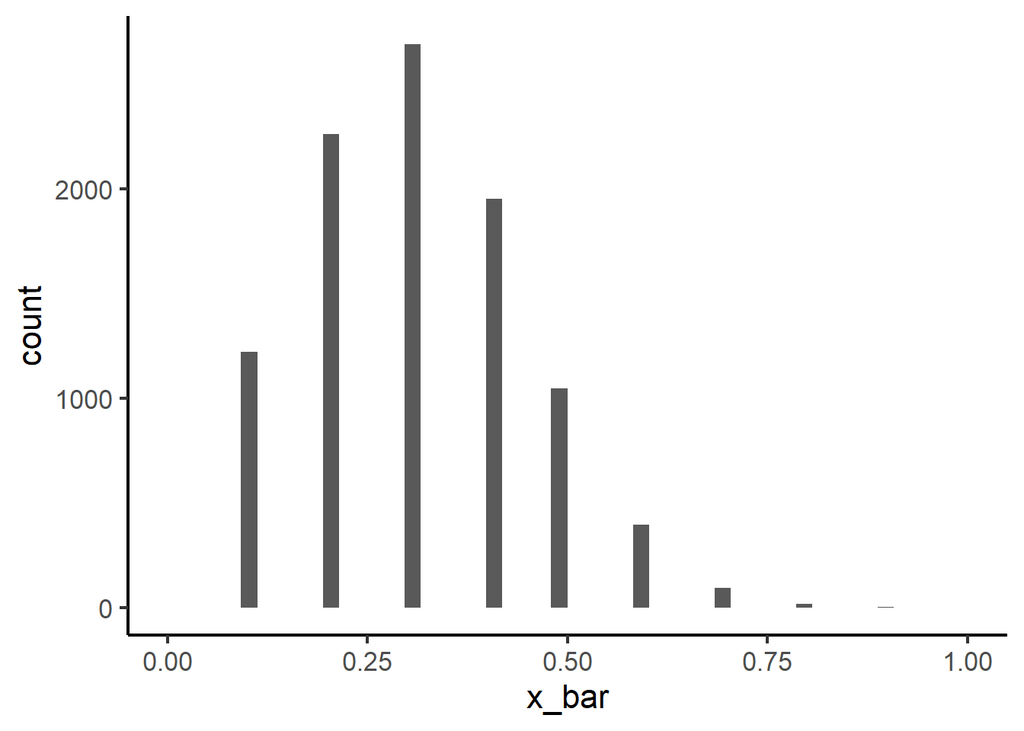

```r
bern_means10 <- data.frame(bernoulli_pop) %>%
  rep_sample_n(size = 10, reps = 10000, replace = TRUE) %>%
  summarise(x_bar = mean(bernoulli_pop))

ggplot(data = bern_means10, aes(x = x_bar)) +
  geom_histogram(bins = 50) +
  xlim(0, 1)
```

- Moderate sample: $n$ = 50

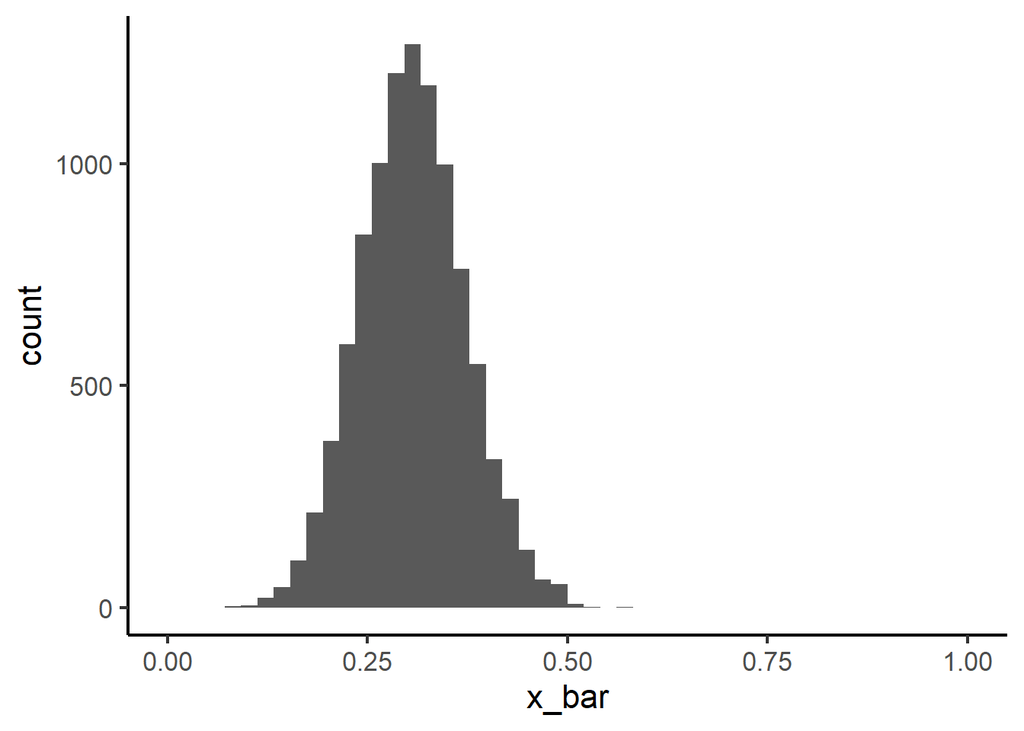

```r
bern_means50 <- data.frame(bernoulli_pop) %>%
  rep_sample_n(size = 50, reps = 10000, replace = TRUE) %>%
  summarise(x_bar = mean(bernoulli_pop))

ggplot(data = bern_means50, aes(x = x_bar)) +
  geom_histogram(bins = 50) +
  xlim(0, 1)
```

- Large sample: $n$ = 100

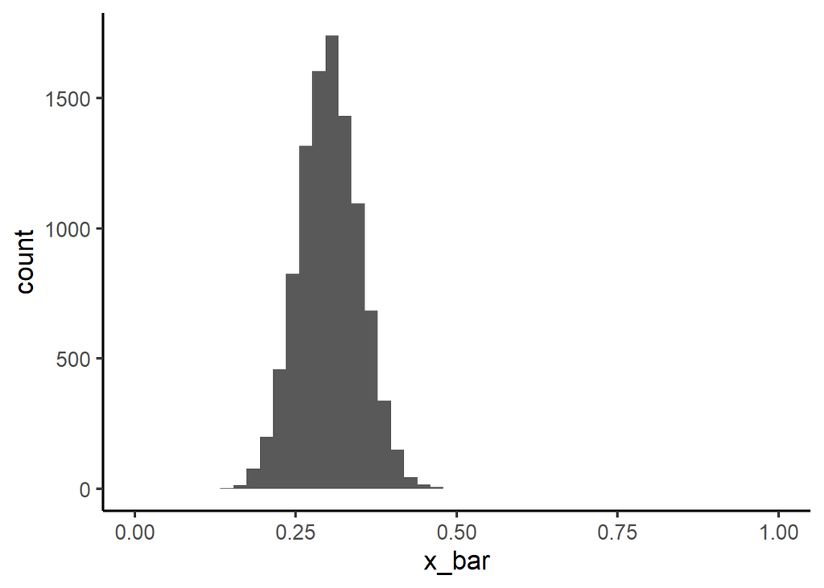

```r
bern_means100 <- data.frame(bernoulli_pop) %>%
  rep_sample_n(size = 100, reps = 10000, replace = TRUE) %>%
  summarise(x_bar = mean(bernoulli_pop))

ggplot(data = bern_means100, aes(x = x_bar)) +
  geom_histogram(bins = 50) +
  xlim(0, 1)
```

#### 3.3.3 Compare estimates

- Compare means, standard deviations, and variances for each sample size

```r
mean(bern_means10$x_bar)
```

```
[1] 0.29996
```

```r
mean(bern_means50$x_bar)
```

```
[1] 0.300286
```

```r
mean(bern_means100$x_bar)
```

```
[1] 0.301151
```

```r
sd(bern_means10$x_bar)
```

```
[1] 0.1472554
```

```r
sd(bern_means50$x_bar)
```

```
[1] 0.06461003
```

```r
sd(bern_means100$x_bar)
```

```
[1] 0.04610139
```

```r
var(bern_means10$x_bar)
```

```
[1] 0.02168417
```

```r
var(bern_means50$x_bar)
```

```
[1] 0.004174456
```

```r
var(bern_means100$x_bar)
```

```
[1] 0.002125338
```

- How does each value correspond to what you’d expect based on the mathematically-derived sampling distribution **for a normally distributed population**?
  - $\bar{X} \sim \mathcal{N}(\mu, \frac{\sigma^2}{n})$

### 3.4 Poisson population: $population \sim Poisson(1.5)$

#### 3.4.1 Create a population

- `rpois()` creates a random variable that follows a **Poisson** distribution
  - First argument = Number of observations (population size)
  - Second argument = $\lambda$ (mean and variance)
    - Remember that $\lambda$ is the variance, but we’re going to look at the **standard deviation** which is the *square root* of the variance

```r
poisson_pop <- rpois(1000000, 1.5)
mean(poisson_pop)
```

```
[1] 1.501647
```

```r
sd(poisson_pop)
```

```
[1] 1.226078
```

```r
var(poisson_pop)
```

```
[1] 1.503267
```

- Copy and modify the code above to resample from this new Poisson population

#### 3.4.2 Sample from the population

- Small sample: $n$ = 10

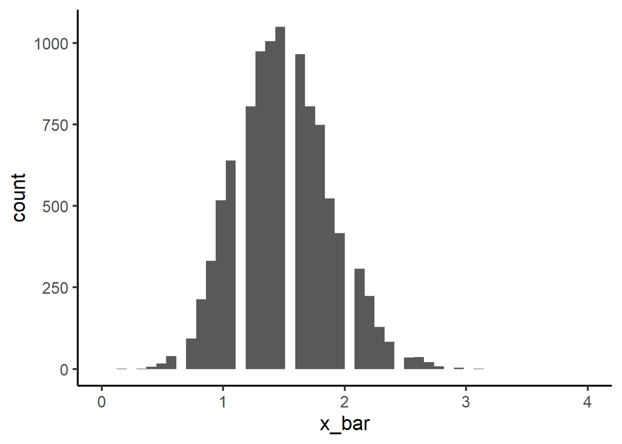

```r
pois_means10 <- data.frame(poisson_pop) %>%
  rep_sample_n(size = 10, reps = 10000, replace = TRUE) %>%
  summarise(x_bar = mean(poisson_pop))

ggplot(data = pois_means10, aes(x = x_bar)) +
  geom_histogram(bins = 50) +
  xlim(0, 4)
```

- Moderate sample: $n$ = 50

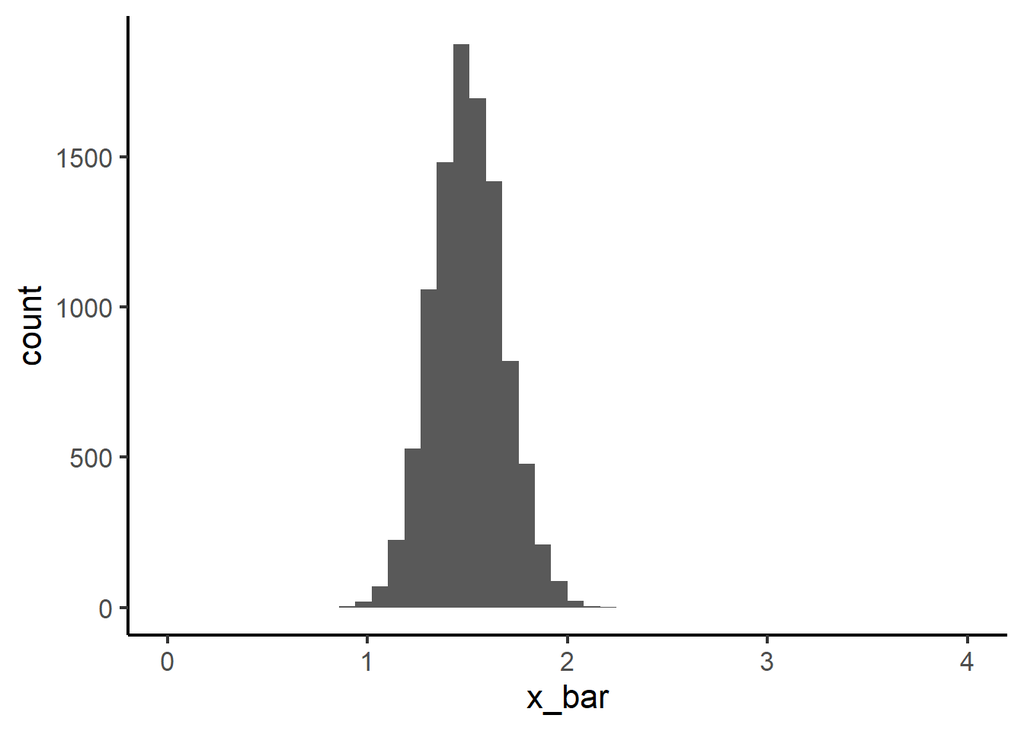

```r
pois_means50 <- data.frame(poisson_pop) %>%
  rep_sample_n(size = 50, reps = 10000, replace = TRUE) %>%
  summarise(x_bar = mean(poisson_pop))

ggplot(data = pois_means50, aes(x = x_bar)) +
  geom_histogram(bins = 50) +
  xlim(0, 4)
```

- Large sample: $n$ = 100

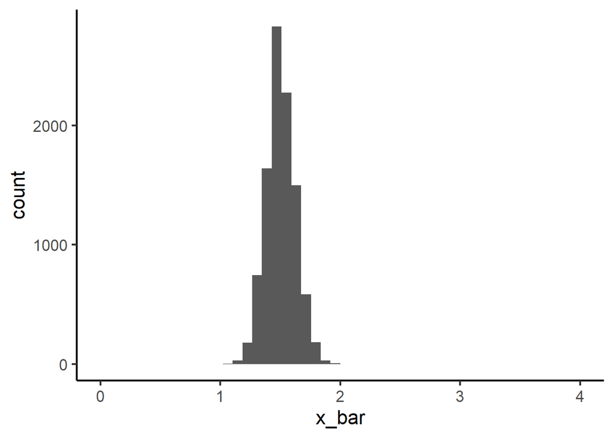

```r
pois_means100 <- data.frame(poisson_pop) %>%
  rep_sample_n(size = 100, reps = 10000, replace = TRUE) %>%
  summarise(x_bar = mean(poisson_pop))

ggplot(data = pois_means100, aes(x = x_bar)) +
  geom_histogram(bins = 50) +
  xlim(0, 4)
```

#### 3.4.3 Compare estimates

- Compare means, standard deviations, and variances for each sample size

```r
mean(pois_means10$x_bar)
```

```
[1] 1.49989
```

```r
mean(pois_means50$x_bar)
```

```
[1] 1.502572
```

```r
mean(pois_means100$x_bar)
```

```
[1] 1.503961
```

```r
sd(pois_means10$x_bar)
```

```
[1] 0.3863003
```

```r
sd(pois_means50$x_bar)
```

```
[1] 0.1733869
```

```r
sd(pois_means100$x_bar)
```

```
[1] 0.1214733
```

```r
var(pois_means10$x_bar)
```

```
[1] 0.1492279
```

```r
var(pois_means50$x_bar)
```

```
[1] 0.03006303
```

```r
var(pois_means100$x_bar)
```

```
[1] 0.01475576
```

- How does each value correspond to what you’d expect based on the mathematically-derived sampling distribution **for a normally distributed population**?
  - $\bar{X} \sim \mathcal{N}(\mu, \frac{\sigma^2}{n})$

## 4 Summarize results

- In general, how does **sample size** impact the **standard error**?
  - i.e., the standard deviation of the sampling distribution?
- Does it seem to matter what the population distribution is?
  - Based on: Visual inspection of the distribution
  - Based on: Estimates of standard error